# Bike Share Project

Joseph Ramaswami

2022-10-31

## Introduction

Cyclistic is a bike sharing company. They have three different pricing plans: single day, full-day pass, and annual membership. Users of the first two plans are referred to as casual riders, the third as members. Cyclistics financial analysts determined that annual memberships are more profitable. Before coming up with a plan to sell more annual memberships, Lily Moreno, CEO of Cyclistic, would like to know **how do annual members and casual riders use Cyclistic bikes differently?**

## Data

### Source

The data consists of observations about bike trips for four quarters starting in Q2 2019 and ending in Q1 2020. This data is public data available under a [data license agreement](https://ride.divvybikes.com/data-license-agreement). Data usable under the license available on the [internet](https://divvy-tripdata.s3.amazonaws.com/index.html).

Data Files

| File Names |
| --- |
| Divvy_Trips_2019_Q2.zip |
| Divvy_Trips_2019_Q3.zip |
| Divvy_Trips_2019_Q4.zip |
| Divvy_Trips_2020_Q1.zip |

### Data Preparation

The data available is inconsistent between the four files. The data will be standardized to contain the following variables:

Data Dictionary

| Variable | Datatype | Description |
| --- | --- | --- |
| ride_id | character | An unique id for a given ride. |
| rideable_type | character | Before 2020 this was the id for the bike ridden. After 2020 it is the type of bike ridden. |
| started_at | date-time | Date and time the ride started. |
| ended_at | date-time | Date and time the ride ended. |
| start_station_name | character | Name of station where ride started. |
| start_station_id | number | Unique id for station where ride started. |
| end_station_name | character | Name of station where ride ended. |
| end_station_id | number | Unique id for station where ride ended. |
| member_casual | character | Type of rider: ‘member’ or ‘casual’. |

There are several steps required to clean and standardize the data.

1. Compatible variables in files from 2019 are renamed to be consistent with those in the 2020 data file.
2. `ride_id` and `rideable_type` in 2019 data files are converted into character data so that they can stack with the new character based variables used in data from 2020 onward.
3. There are observations 130 trips where `started_at` is *after* `ended_at`. These observations will be removed.
4. The `member_casual` data must be fixed. In the 2019 data files, the `member_casual` variable had values of “Subscriber” and “Customer”; these will be replaced with “member” and “casual”, respectively. This is consistent with data gathered from 2020 onward.
5. A single observation has missing values for the `end_station_name` and the `end_station_id`; this observation will be dropped.
6. The specifications for this project mention bicycles removed for quality control reasons. They have starting or ending station names of “HQ QR” and there are 3768 observations that will be removed.

The resulting clean data set consists of 3876041 observations.

## Analysis

### Trip start day by rider type

Overall, members take more trips then casual users. However, we can see from the figure below that casual members appear to take more of their trips on the weekend, where members take the more trips on weekdays. This may indicate that members are more likely commuting to work by bicycle.

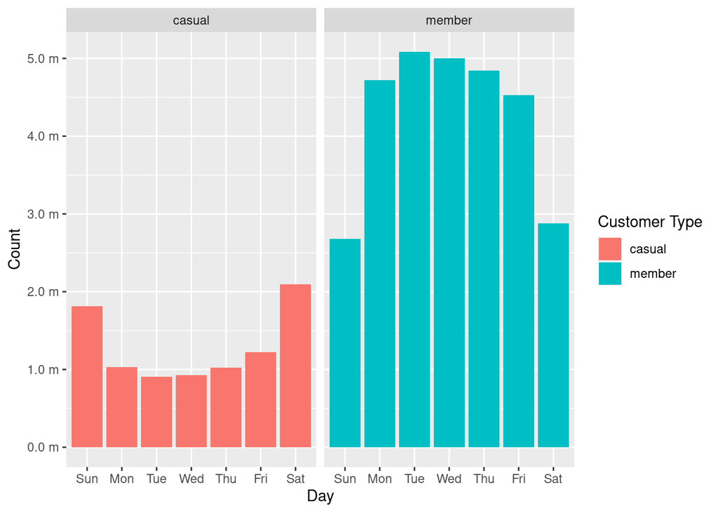

### Trip start time by weekday by rider type

The figure below adds additional support to the hypothesis that members are bicycle commuters. There are visible increases in trip count during rush hours for members on weekdays. This trend is not visible in casual riders.

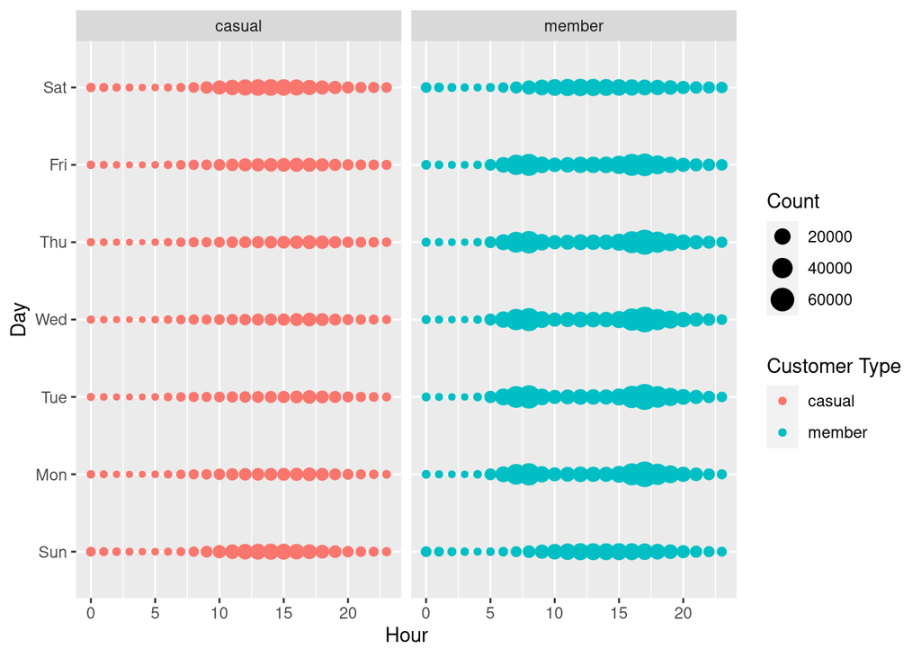

### Duration of ride by rider type

Casual riders tend to have rides of longer duration. This is additional support for the hypothesis that members are bicycle commuters, as members are not taking extended trips because of the necessity to arrive at work or get home in a timely manner.

Summary Statistics for Duration in Seconds by Rider Type

| Member Type | Mean | Min | Q1 | Median | Q3 | Max | IQR |
| --- | --- | --- | --- | --- | --- | --- | --- |
| casual | 3552.7502 | 2 | 910 | 1546 | 2715 | 9387024 | 1805 |
| member | 849.9909 | 1 | 362 | 589 | 971 | 9056634 | 609 |

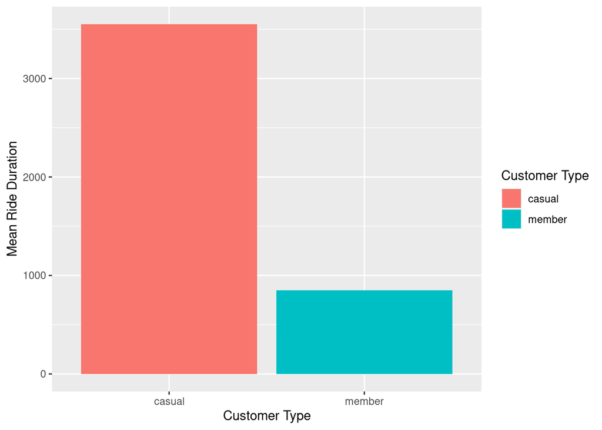

### Percent of rides by rider type by station

There are 642 stations in our data set. The number of stations makes visualizing differences between stations for each rider type unwieldy. Instead, we will look for stations with a relatively large difference between the percentage of riders of the given type starting or ending at a station.

Start Stations With More than 1% Difference Between Rider Types

| Station Name | Pct. of Member Rides | Pct. Of Casual Rides | Difference |
| --- | --- | --- | --- |
| Dusable Harbor | 0.16 | 1.41 | 1.25 |
| Adler Planetarium | 0.17 | 1.33 | 1.16 |
| Shedd Aquarium | 0.20 | 2.30 | 2.10 |
| Lake Shore Dr & Monroe St | 0.36 | 4.40 | 4.04 |
| Millennium Park | 0.43 | 2.43 | 2.00 |
| Michigan Ave & Oak St | 0.48 | 2.40 | 1.92 |
| Streeter Dr & Grand Ave | 0.50 | 5.92 | 5.42 |
| Lake Shore Dr & North Blvd | 0.53 | 2.12 | 1.59 |
| Theater on the Lake | 0.58 | 1.70 | 1.12 |
| Clinton St & Washington Blvd | 1.47 | 0.31 | 1.16 |
| Clinton St & Madison St | 1.55 | 0.44 | 1.11 |
| Canal St & Adams St | 1.75 | 0.43 | 1.32 |

End Stations With More than 1% Difference Between Rider Types

| Station Name | Pct. of Member Rides | Pct. Of Casual Rides | Difference |
| --- | --- | --- | --- |
| Adler Planetarium | 0.17 | 1.19 | 1.02 |
| Shedd Aquarium | 0.19 | 1.85 | 1.66 |
| Lake Shore Dr & Monroe St | 0.35 | 3.44 | 3.09 |
| Millennium Park | 0.42 | 2.83 | 2.41 |
| Michigan Ave & Oak St | 0.48 | 2.66 | 2.18 |
| Streeter Dr & Grand Ave | 0.48 | 7.48 | 7.00 |
| Theater on the Lake | 0.59 | 2.13 | 1.54 |
| Lake Shore Dr & North Blvd | 0.65 | 2.60 | 1.95 |
| Clinton St & Madison St | 1.49 | 0.33 | 1.16 |
| Clinton St & Washington Blvd | 1.60 | 0.28 | 1.32 |
| Canal St & Adams St | 1.64 | 0.32 | 1.32 |

As seen in the above tables, there are several stations with greater than 1% difference by rider type in the percentage of rides that start or end at the given station. However, more statistical studies should be undertaken to determine if the differences are significant.

## Supplementary Analysis

Data collected in 2020 includes latitude and longitude for the starting and ending points of each trip. Though a limited sample, I thought it worth looking at the extra data for any possible insights.

### Start and end location by rider type

Geographically, there does not appear to be any significant difference between where members and casual riders start or end their trips. This is contradictory to the differences in start and end station mentioned above, emphasizing the need for more sophisticated statistical analysis of geographical data.

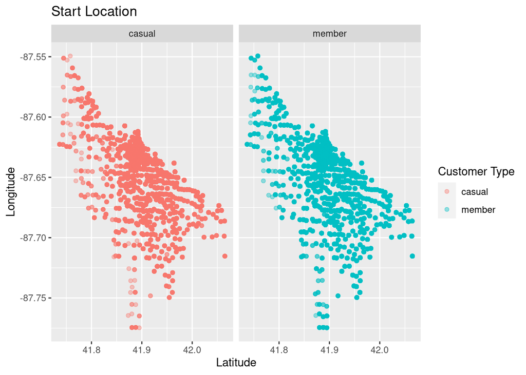

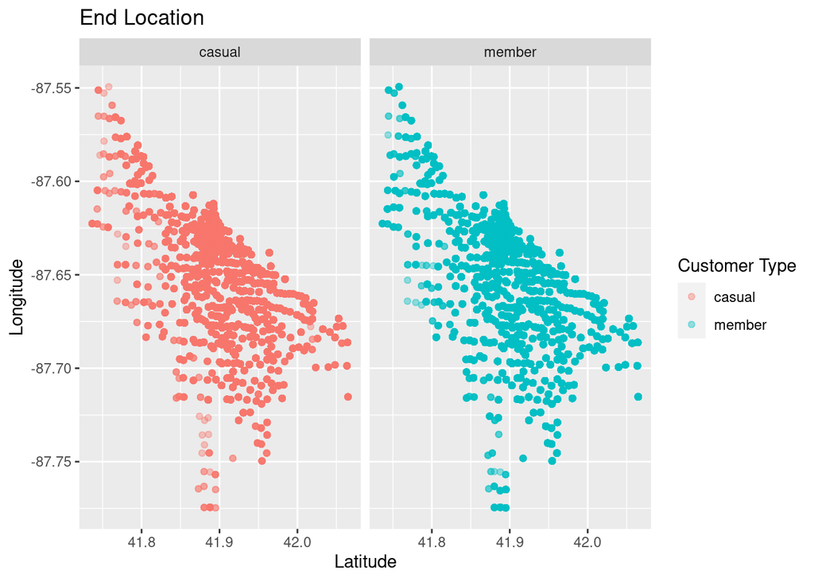

## Analysis Summary

### Members appear to be bicycle commuters

The distribution of trips by day of the week and the pattern of increased trips during rush hour for members supports the hypothesis that members are commuting to work by bicycle.

### Casual riders take longer trips

This could be further evidence that members are bicycle commuters.

### Analysis of geographical data is unclear

There may be some differences in the start and end stations used by members and casual riders but the lack of geographical differences by latitude and longitude indicate that further statistical analysis is necessary to determine if there are any geographical differences between members and casual riders.

## Recommendations

### Cyclistic should target bicycle commuters

Cyclistic is looking to increase the number of members. The data analysis supports that many current members are bicycle commuters. Bicycle commuters that are not members represents an appearing marketing segment to target.

### Convert casual bicycle commuters into members

Cyclistic should make an effort to convert casual riders that currently commute by bicycle into members. A possible marketing effort could be to actively advertise membership at bicycle stations during rush hours.

### Recruit new bicycle commuters

Cyclistic should attempt to convert other types of commuters into bicycle commuters. Cyclistic could partner with local businesses to make other types of commuters aware of the advantages of bicycle commuting and offer joint promotions with those businesses.